# IE582_HW1

yasemin gokdag

October 18, 2018

## Task1

For this task, the upload required library, and read data is read as follows

```r
require(data.table)
require(anytime)
require(ggplot2)

matchdata <- readRDS('C:/Users/yasemin/Downloads/df9b1196-e3cf-4cc7-9159-f236fe738215_matches (1).rds', refhook = NULL)
matchdata <- as.data.table(matchdata)

odds <- readRDS('C:/Users/yasemin/Downloads/df9b1196-e3cf-4cc7-9159-f236fe738215_odd_details (1).rds', refhook = FALSE)
odds <- as.data.table(odds)
```

### Part A

After the data is uploaded, first I checked whether there are duplicate rows or not. Match data had duplicate rows, those are cleaned. Odds data is unique.

Having cleaned the data, I joined two tables and filtered accoring to the description on task1, any match that is not played yet is removed since they are out of scope.

Initial bets and final bets of bookmakers are found and seperated as two different data tables. All calculations were performed on both seperately.

Then, odds are tranformed into probabilities. Ratio 1/odds is normalized with bookmakers total (1/odd) value as described in the task introduction

Top 8 bookmakers are chosen based on the count of distinct matches that they offered odds.

In order to examine density, a histogram was drawed as follows :

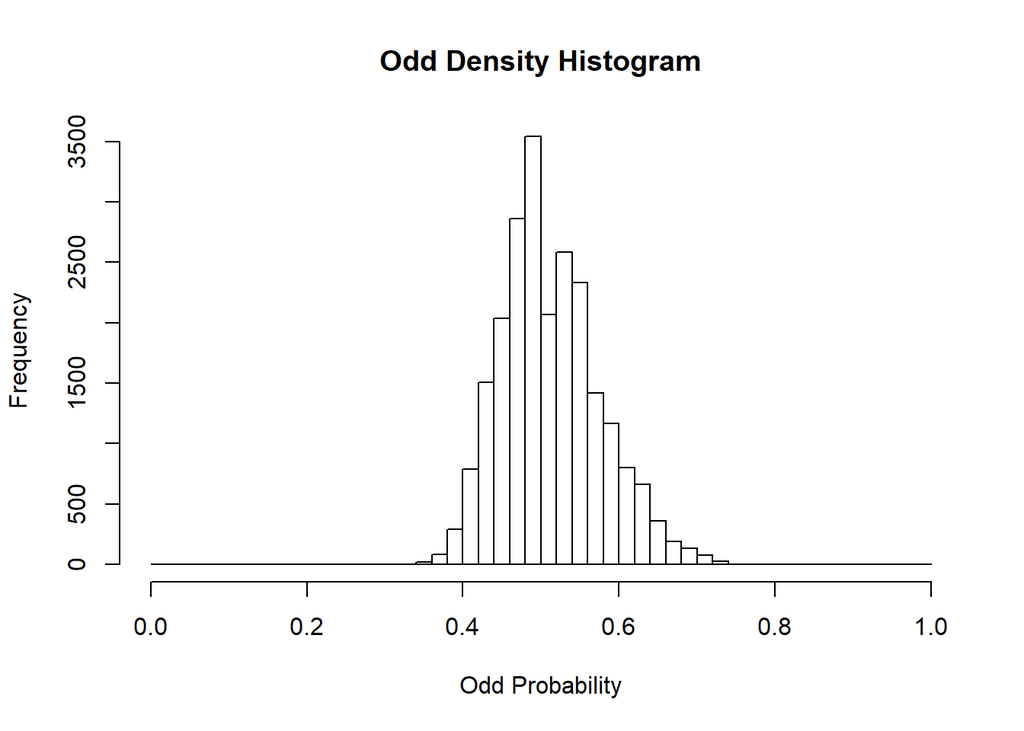

Based on the histogram, bins were selected as follows:

```
##    Lower Upper id
## 1:  0.35  0.40  1
## 2:  0.40  0.45  2
## 3:  0.45  0.50  3
## 4:  0.50  0.55  4
## 5:  0.55  0.60  5
## 6:  0.60  0.65  6
## 7:  0.65  0.70  7
## 8:  0.70  0.75  8
```

Then probabilities are assigned to bins, bin information is combined with calculated probabilites. Score data is splitted and actual over/total matches fraction is calculated per bookmaker per bin.

Initial bets plot is as follows :

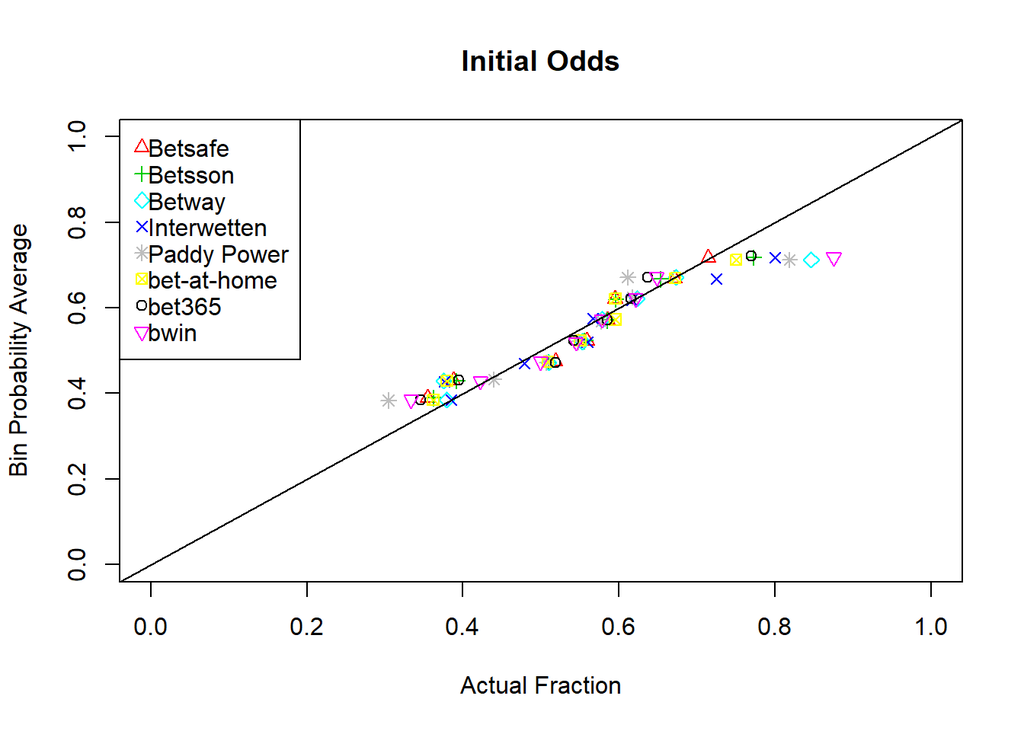

Final bets plot is as follows :

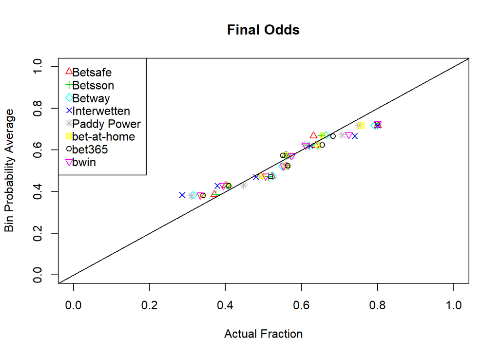

As seen in plots, accuracy over bins get better when the bets are finalized. On initial bets, bookmakers such as BetSafe, bet-at-home,Betsson, bet365 perform well. On final bets, the ones that were successful on initial bets are still good, the bookmaker Paddy Power significantly improves its performance. As actual over fraction moves away from 0.5, we see that accuracy deteriorates. It is worse on initial odds, but better on final odds. This might be because bookmakers can update their odds while the match is played

### Part B

For this part, bookmaker bet365 is examined since it offered odds for the maximum number of matchs. Than, similar to what is done on part a, odd probabilites and actual over fractions are calculated per year per bin

The yearly performance per bin is as follows

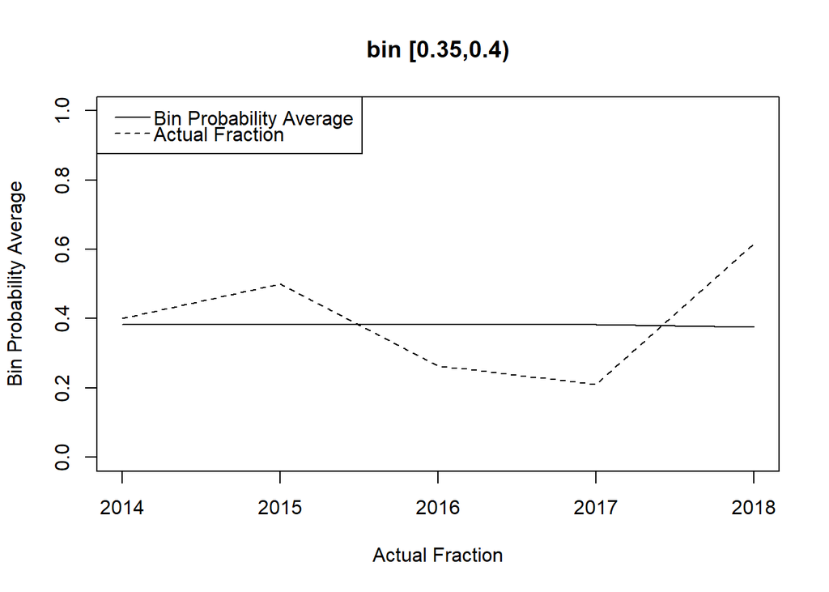

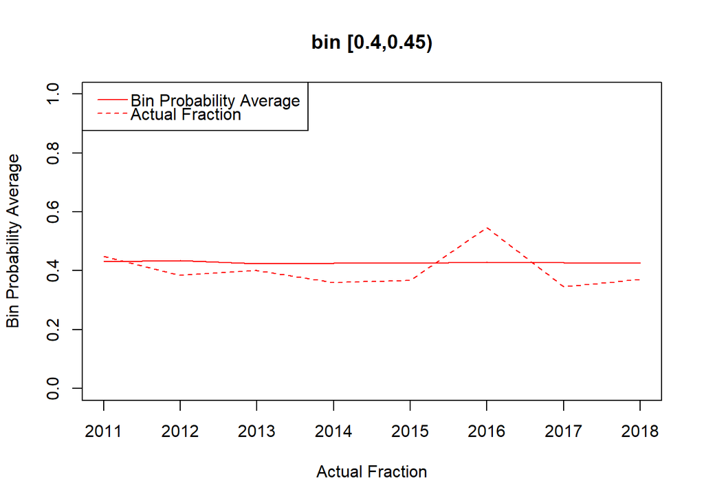

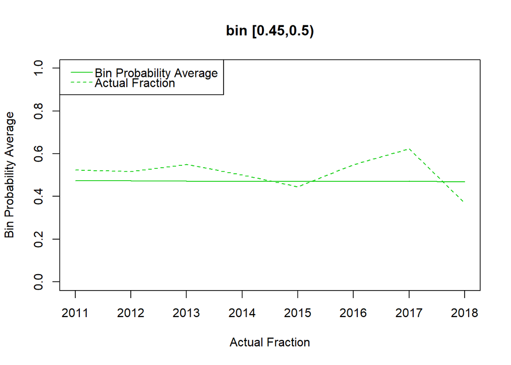

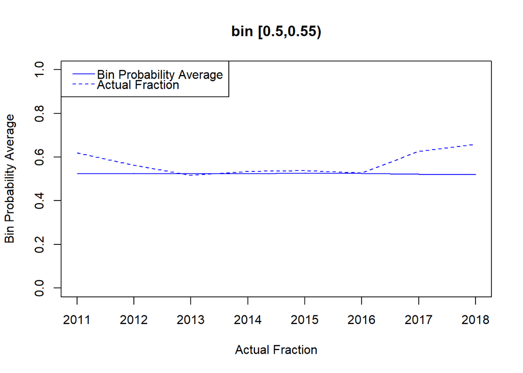

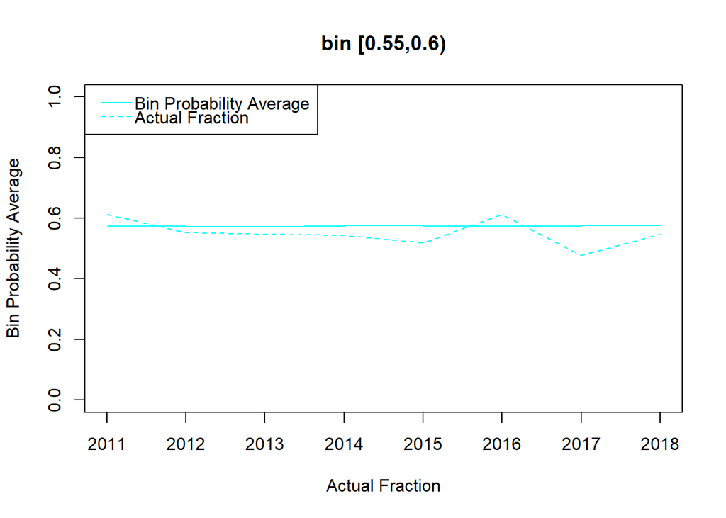

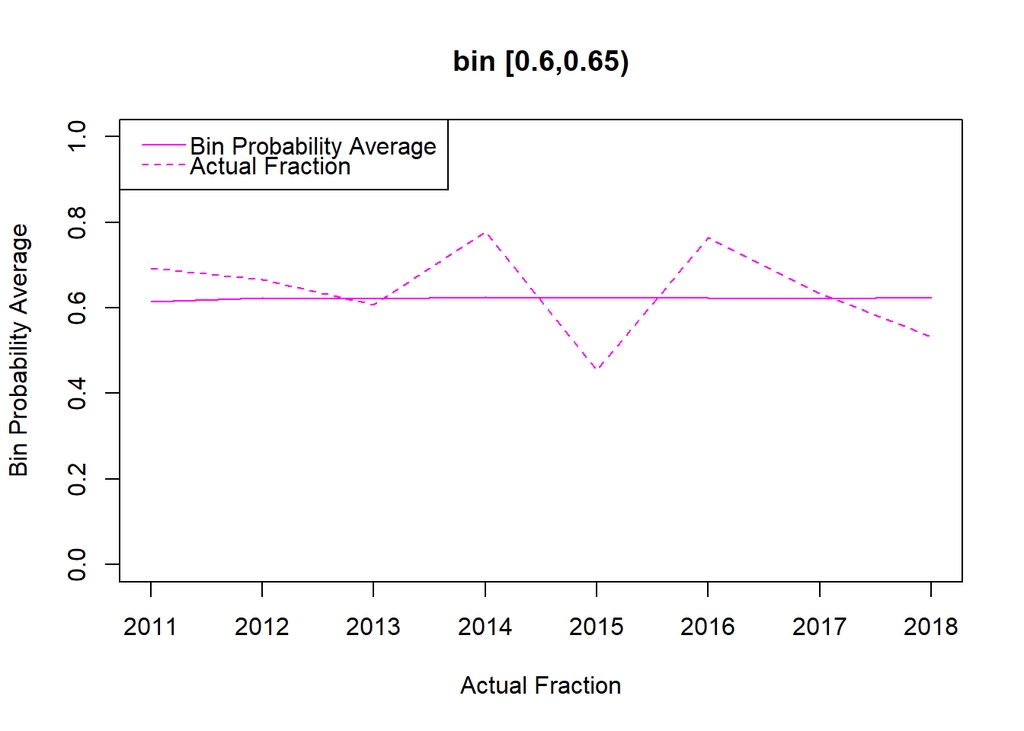

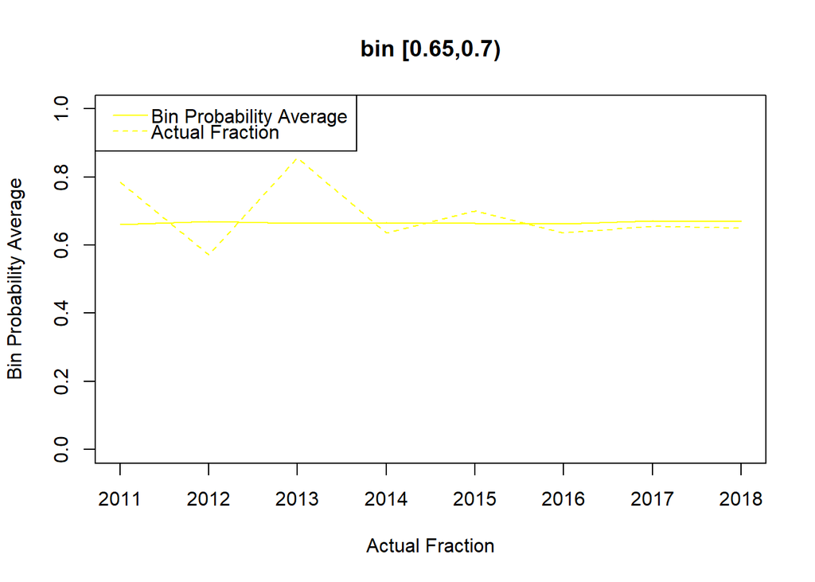

[figure not shown]

For some bins, like bin [0.65,0.7) , the performance gets better as the years passed. However, we cannot say that this holds for all bins. For example bin [0.5,0.55) has worse performance on recent years. In general, the results are consistent with what we observed on part a as expected. As the fraction moves away from 0.5, accurracy deteriorates here as well. The bookmaker’s variance from actual fraction stays at a certain level, this might explain its overall success.

## Task 2

For this task, I picked the bookmaker that I have evaluated on part a. For this bookmaker, I aimed to find a match so that the odds on different odd types drastically changes. I was hoping to find a strict transition from one oddtype to the other, such change might hhave been interpreted as an information change. However, I was not able to find such drastic change on odds.

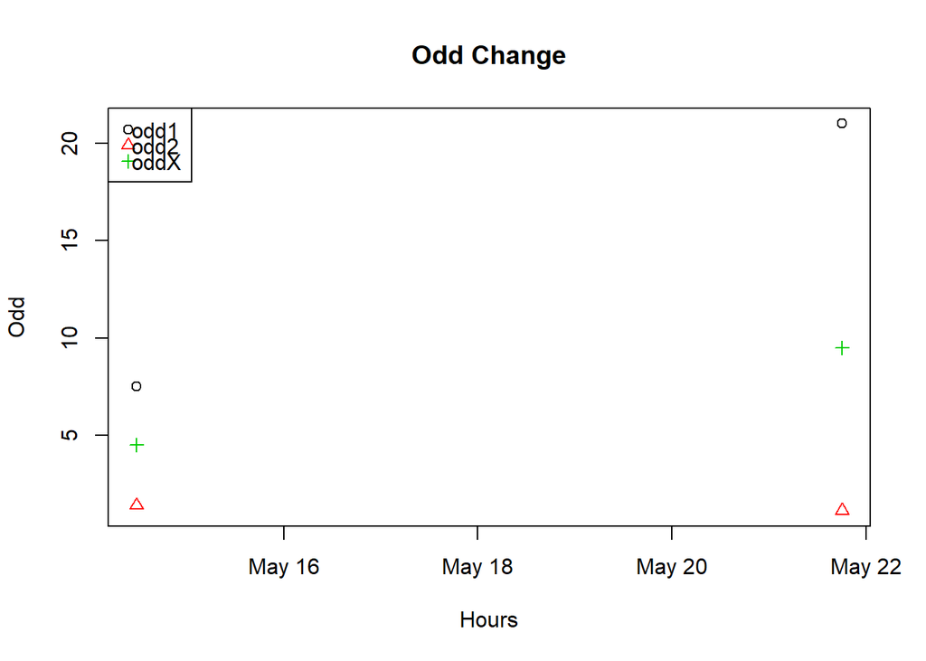